# Prédiction prix de vente de maisons

## Introduction

Pistes à suivre:

- Importer les bibliothèques pandas, matplotlib et numpy dans notre environnement. Importer aussi les classes dont vous avez besoin depuis scikit-learn.
- Lire AmesHousing.tsv dans un dataframe pandas qu'on nommera data.
- Pour les fonction suivantes, je vous recommande de les créer dans les premières cellules du notebook afin de pouvoir faire des expériences et les mettre à jour plus tard si besoin.
  - Créer une fonction qu'on peut nommer transform_features() qui, pour le moment, retourne seulement le dataframe train.
  - Créer une fonction qu'on nommera select_features() qui, pour le moment, retourne seulement les colonnes 'Gr Liv Area' et 'SalePrice' du dataframe train.
  - Créer une fonction nommée train_and_test() qui, pour le moment:
    > - Sélectionne les 1460 premières lignes du dataframe data et les assigne à la variable train.
    > - Sélectionne les lignes restantes du dataframe data et les assigne à la variable test.
    > - Entraine un modèle en utilisant toutes les colonnes numériques à l'exception de la colonne 'SalePrice' (la colonne cible) du dataframe que retourne la fonction select_features().
    > - Fait une prédiction sur le set de test et calcule la valeur RMSE.

```python
import pandas as pd
import numpy as np
import matplotlib.pyplot as plt
from sklearn.model_selection import KFold
from sklearn.metrics import mean_squared_error
from sklearn import linear_model
from sklearn.model_selection import KFold

pd.set_option('display.max_columns', 500)
```

```python
data = pd.read_csv("AmesHousing.tsv", delimiter='\t')
```

```python
print(data.shape)
print(len(str(data.shape))*'-')
print(data.dtypes.value_counts())
data.head()
```

```
(2930, 82)
----------
object     43
int64      28
float64    11
dtype: int64
```

|  | Order | PID | MS SubClass | MS Zoning | Lot Frontage | Lot Area | Street | Alley | Lot Shape | Land Contour | Utilities | Lot Config | Land Slope | Neighborhood | Condition 1 | Condition 2 | Bldg Type | House Style | Overall Qual | Overall Cond | Year Built | Year Remod/Add | Roof Style | Roof Matl | Exterior 1st | Exterior 2nd | Mas Vnr Type | Mas Vnr Area | Exter Qual | … |
| --- | --- | --- | --- | --- | --- | --- | --- | --- | --- | --- | --- | --- | --- | --- | --- | --- | --- | --- | --- | --- | --- | --- | --- | --- | --- | --- | --- | --- | --- | --- |
| 0 | 1 | 526301100 | 20 | RL | 141.0 | 31770 | Pave | NaN | IR1 | Lvl | AllPub | Corner | Gtl | NAmes | Norm | Norm | 1Fam | 1Story | 6 | 5 | 1960 | 1960 | Hip | CompShg | BrkFace | Plywood | Stone | 112.0 | TA | … |
| 1 | 2 | 526350040 | 20 | RH | 80.0 | 11622 | Pave | NaN | Reg | Lvl | AllPub | Inside | Gtl | NAmes | Feedr | Norm | 1Fam | 1Story | 5 | 6 | 1961 | 1961 | Gable | CompShg | VinylSd | VinylSd | None | 0.0 | TA | … |
| 2 | 3 | 526351010 | 20 | RL | 81.0 | 14267 | Pave | NaN | IR1 | Lvl | AllPub | Corner | Gtl | NAmes | Norm | Norm | 1Fam | 1Story | 6 | 6 | 1958 | 1958 | Hip | CompShg | Wd Sdng | Wd Sdng | BrkFace | 108.0 | TA | … |
| 3 | 4 | 526353030 | 20 | RL | 93.0 | 11160 | Pave | NaN | Reg | Lvl | AllPub | Corner | Gtl | NAmes | Norm | Norm | 1Fam | 1Story | 7 | 5 | 1968 | 1968 | Hip | CompShg | BrkFace | BrkFace | None | 0.0 | Gd | … |
| 4 | 5 | 527105010 | 60 | RL | 74.0 | 13830 | Pave | NaN | IR1 | Lvl | AllPub | Inside | Gtl | Gilbert | Norm | Norm | 1Fam | 2Story | 5 | 5 | 1997 | 1998 | Gable | CompShg | VinylSd | VinylSd | None | 0.0 | TA | … |

```python
def transform_features(df):
    return df

def select_features(df):
    return df[["Gr Liv Area", "SalePrice"]]

def train_and_test(df):
    train = df[:1460]
    test = df[1460:]
    numeric_train = train.select_dtypes(include=['integer', 'float'])
    numeric_test = test.select_dtypes(include=['integer', 'float'])
    features = numeric_train.columns.drop("SalePrice")

    # Entrainement
    lr = linear_model.LinearRegression()
    lr.fit(train[features], train["SalePrice"])

    # Prédiction
    predictions = lr.predict(test[features])
    mse = mean_squared_error(test["SalePrice"], predictions)
    rmse = np.sqrt(mse)

    return rmse
```

```python
transform_df = transform_features(data)
filtered_df = select_features(transform_df)
rmse = train_and_test(filtered_df)
rmse
```

```
57088.25161263909
```

## Traitement des caractéristiques

Gérer les valeurs manquantes:

- Toutes les colonnes:
  - Supprimer celles qui ont 5% ou plus de valeurs manquantes pour le moment.
- Colonnes texte:
  - Supprimer toute colonne contenant 1 valeur manquante ou plus pour le moment.
- Colonnes numériques:
  - Pour les colonnes contenant des valeurs manquantes, remplacer par les valeurs les plus fréquentes de la colonne
1. Toutes les colonnes: supprimer celles qui ont 5% ou plus de valeurs manquantes pour le moment.

```python
num_missing = data.isnull().sum()

# Filtrer l'objet Series sur les colonnes contenant >5% de valeurs manquantes
drop_missing_cols = num_missing[(num_missing > len(data)/20)].sort_values()

# Supprimer ces colonnes dans le DataFrame. Noter l'utilisation de l'accesseur .index
data = data.drop(drop_missing_cols.index, axis=1)
data.shape[1]
```

```
71
```

1. Colonnes texte: supprimer toute colonne contenant au moins une valeur manquante pour le moment.

```python
text_mv_counts = data.select_dtypes(include=['object']).isnull().sum().sort_values(
    ascending=False)

# Filtrer l'objet Series sur les colonnes contenant au moins une valeur manquante
drop_missing_cols_2 = text_mv_counts[text_mv_counts > 0]
data = data.drop(drop_missing_cols_2.index, axis=1)
data.shape[1]
```

```
64
```

1. Colonnes numériques: pour les colonnes contenant des valeurs manquantes, remplacer par la valeur la plus fréquente de la colonne

```python
# Calculer le nombre de valeurs manquantes colonne par colonne
num_missing = data.select_dtypes(include=['int', 'float']).isnull().sum()

fixable_numeric_missing_cols = num_missing[(num_missing < len(data)/20) &
                                   (num_missing > 0)].sort_values()
fixable_numeric_missing_cols
```

```
BsmtFin SF 1       1
BsmtFin SF 2       1
Bsmt Unf SF        1
Total Bsmt SF      1
Garage Cars        1
Garage Area        1
Bsmt Full Bath     2
Bsmt Half Bath     2
Mas Vnr Area      23
dtype: int64
```

```python
# Calculer la valeur la plus commune pour chaque colonne.
replacement_values_dict = data[fixable_numeric_missing_cols.index].mode().to_dict(
    orient='records')[0]
replacement_values_dict
```

```
{'BsmtFin SF 1': 0.0,
 'BsmtFin SF 2': 0.0,
 'Bsmt Unf SF': 0.0,
 'Total Bsmt SF': 0.0,
 'Garage Cars': 2.0,
 'Garage Area': 0.0,
 'Bsmt Full Bath': 0.0,
 'Bsmt Half Bath': 0.0,
 'Mas Vnr Area': 0.0}
```

```python
# Remplacer les valeurs manquantes.
data = data.fillna(replacement_values_dict)

## Vérifier que toutes les colonnes ont bien 0 valeur manquante
data.isnull().sum().value_counts()
```

```
0    64
dtype: int64
```

Quelles nouvelles caractéristiques pouvons-nous créer pour mieux capturer les informations contenues dans certaines caractéristiques?

```python
years_sold = data['Yr Sold'] - data['Year Built']
years_sold[years_sold < 0]
```

```
2180   -1
dtype: int64
```

```python
years_since_remod = data['Yr Sold'] - data['Year Remod/Add']
years_since_remod[years_since_remod < 0]
```

```
1702   -1
2180   -2
2181   -1
dtype: int64
```

```python
# Créer 2 nouvelles colonnes
data['Years Before Sale'] = years_sold
data['Years Since Remod'] = years_since_remod
```

```python
# Supprimer les lignes avec des valeurs négatives pour ces nouvelles caractéristiques
data = data.drop([1702, 2180, 2181], axis=0)
```

```python
# Plus besoin des colonnes de l'année d'origine
data = data.drop(["Year Built", "Year Remod/Add"], axis = 1)
```

Supprimer les colonnes qui:

- Ne sont pas utiles pour le Machine Learning
- Fuite des données au sujet de la vente finale (cf. documentation dataset)

```python
# Supprimer les colonnes qui ne sont pas utiles pour le ML
data = data.drop(["PID", "Order"], axis=1)

# Supprimer les colonnes qui font fuiter des informations sur la vente finale
data = data.drop(["Mo Sold", "Sale Condition", "Sale Type", "Yr Sold"], axis=1)
```

```python
data.head()
```

|  | MS SubClass | MS Zoning | Lot Area | Street | Lot Shape | Land Contour | Utilities | Lot Config | Land Slope | Neighborhood | Condition 1 | Condition 2 | Bldg Type | House Style | Overall Qual | Overall Cond | Roof Style | Roof Matl | Exterior 1st | Exterior 2nd | Mas Vnr Area | Exter Qual | Exter Cond | Foundation | BsmtFin SF 1 | BsmtFin SF 2 | Bsmt Unf SF | Total Bsmt SF | Heating | … |
| --- | --- | --- | --- | --- | --- | --- | --- | --- | --- | --- | --- | --- | --- | --- | --- | --- | --- | --- | --- | --- | --- | --- | --- | --- | --- | --- | --- | --- | --- | --- |
| 0 | 20 | RL | 31770 | Pave | IR1 | Lvl | AllPub | Corner | Gtl | NAmes | Norm | Norm | 1Fam | 1Story | 6 | 5 | Hip | CompShg | BrkFace | Plywood | 112.0 | TA | TA | CBlock | 639.0 | 0.0 | 441.0 | 1080.0 | GasA | … |
| 1 | 20 | RH | 11622 | Pave | Reg | Lvl | AllPub | Inside | Gtl | NAmes | Feedr | Norm | 1Fam | 1Story | 5 | 6 | Gable | CompShg | VinylSd | VinylSd | 0.0 | TA | TA | CBlock | 468.0 | 144.0 | 270.0 | 882.0 | GasA | … |
| 2 | 20 | RL | 14267 | Pave | IR1 | Lvl | AllPub | Corner | Gtl | NAmes | Norm | Norm | 1Fam | 1Story | 6 | 6 | Hip | CompShg | Wd Sdng | Wd Sdng | 108.0 | TA | TA | CBlock | 923.0 | 0.0 | 406.0 | 1329.0 | GasA | … |
| 3 | 20 | RL | 11160 | Pave | Reg | Lvl | AllPub | Corner | Gtl | NAmes | Norm | Norm | 1Fam | 1Story | 7 | 5 | Hip | CompShg | BrkFace | BrkFace | 0.0 | Gd | TA | CBlock | 1065.0 | 0.0 | 1045.0 | 2110.0 | GasA | … |
| 4 | 60 | RL | 13830 | Pave | IR1 | Lvl | AllPub | Inside | Gtl | Gilbert | Norm | Norm | 1Fam | 2Story | 5 | 5 | Gable | CompShg | VinylSd | VinylSd | 0.0 | TA | TA | PConc | 791.0 | 0.0 | 137.0 | 928.0 | GasA | … |

```python
def transform_features(df, percent_missing=0.05):
    num_missing = df.isnull().sum()
    drop_missing_cols = num_missing[(num_missing > len(df)*percent_missing)].sort_values()
    df = df.drop(drop_missing_cols.index, axis=1)

    text_mv_counts = df.select_dtypes(include=['object']).isnull().sum().sort_values(
        ascending=False)
    drop_missing_cols_2 = text_mv_counts[text_mv_counts > 0]
    df = df.drop(drop_missing_cols_2.index, axis=1)

    num_missing = df.select_dtypes(include=['int', 'float']).isnull().sum()
    fixable_numeric_cols = num_missing[(num_missing < len(df)*percent_missing) &
                                       (num_missing > 0)].sort_values()
    replacement_values_dict = df[fixable_numeric_cols.index].mode().to_dict(
        orient='records')[0]
    df = df.fillna(replacement_values_dict)

    years_sold = df['Yr Sold'] - df['Year Built']
    years_since_remod = df['Yr Sold'] - df['Year Remod/Add']
    df['Years Before Sale'] = years_sold
    df['Years Since Remod'] = years_since_remod
    df = df.drop([1702, 2180, 2181], axis=0)
    df = df.drop(["PID", "Order", "Mo Sold", "Sale Condition", "Sale Type", "Year Built",
                  "Year Remod/Add"], axis=1)

    return df

def select_features(df):
    return df[["Gr Liv Area", "SalePrice"]]

def train_and_test(df):
    train = df[:1460]
    test = df[1460:]
    numeric_train = train.select_dtypes(include=['integer', 'float'])
    numeric_test = test.select_dtypes(include=['integer', 'float'])
    features = numeric_train.columns.drop("SalePrice")

    # Entrainement
    lr = linear_model.LinearRegression()
    lr.fit(train[features], train["SalePrice"])

    # Prédiction
    predictions = lr.predict(test[features])
    mse = mean_squared_error(test["SalePrice"], predictions)
    rmse = np.sqrt(mse)

    return rmse
```

```python
data = pd.read_csv("AmesHousing.tsv", delimiter="\t")
transform_df = transform_features(data)
filtered_df = select_features(transform_df)
rmse = train_and_test(filtered_df)
rmse
```

```
55275.367312413066
```

## Sélection des caractéristiques

Pistes à suivre:

- Générer une heatmap de la matrice de corrélation des caractéristiques numériques du dataset de training.
  - Quelles sont les caractéristiques en corrélation étroite avec notre colonne cible 'SalePrice'?
  - Calculer les coefficients de corrélation pour les colonnes qui semblent bien corréler avec 'SalePrice'. Parce que nous avons un pipeline en place, il est facile d'essayer différentes caractéristiques et de voir quelles caractéristiques génèrent un meilleur score de validation croisée.
- Quelles colonnes du DataFrame doivent être converties en type de données catégorique? Toutes les colonnes marquées comme nominal dans la documentation sont candidates à être converties en type catégorie. Voici d'autres éléments auxquels vous devriez penser:
  - Si une colonne de type catégorie contient des centaines de valeurs uniques (ou catégories), devriez-vous la conserver? Si vous créez des colonnes factices avec les différentes catégories, des centaines de colonnes devront être rajoutées dans le DataFrame.
  - Quelles colonnes catégoriques ont quelques valeurs uniques mais plus de 95% de valeurs de la colonne appartiennent à une catégorie spécifique? Cela serait similaire à une caractéristique numérique à faible variance (aucune variabilité dans les données que le modèle doit capturer).
- Quelles colonnes sont actuellement numériques mais doivent plutôt être codées en tant que catégories (car les nombres n'ont aucune signification sémantique)?
- Comment pouvons-nous explorer quelles colonnes qualitatives corrèlent bien avec 'SalePrice'?
- Mettre à jour la fonction select_features(). Cette fonction devrait inclure les nouveaux DataFrames train et test qui ont été retournés par transform_features().

```python
numerical_df = transform_df.select_dtypes(include=['int', 'float'])
numerical_df.head()
```

|  | MS SubClass | Lot Area | Overall Qual | Overall Cond | Mas Vnr Area | BsmtFin SF 1 | BsmtFin SF 2 | Bsmt Unf SF | Total Bsmt SF | 1st Flr SF | 2nd Flr SF | Low Qual Fin SF | Gr Liv Area | Bsmt Full Bath | Bsmt Half Bath | Full Bath | Half Bath | Bedroom AbvGr | Kitchen AbvGr | TotRms AbvGrd | Fireplaces | Garage Cars | Garage Area | Wood Deck SF | Open Porch SF | Enclosed Porch | 3Ssn Porch | Screen Porch | Pool Area | … |
| --- | --- | --- | --- | --- | --- | --- | --- | --- | --- | --- | --- | --- | --- | --- | --- | --- | --- | --- | --- | --- | --- | --- | --- | --- | --- | --- | --- | --- | --- | --- |
| 0 | 20 | 31770 | 6 | 5 | 112.0 | 639.0 | 0.0 | 441.0 | 1080.0 | 1656 | 0 | 0 | 1656 | 1.0 | 0.0 | 1 | 0 | 3 | 1 | 7 | 2 | 2.0 | 528.0 | 210 | 62 | 0 | 0 | 0 | 0 | … |
| 1 | 20 | 11622 | 5 | 6 | 0.0 | 468.0 | 144.0 | 270.0 | 882.0 | 896 | 0 | 0 | 896 | 0.0 | 0.0 | 1 | 0 | 2 | 1 | 5 | 0 | 1.0 | 730.0 | 140 | 0 | 0 | 0 | 120 | 0 | … |
| 2 | 20 | 14267 | 6 | 6 | 108.0 | 923.0 | 0.0 | 406.0 | 1329.0 | 1329 | 0 | 0 | 1329 | 0.0 | 0.0 | 1 | 1 | 3 | 1 | 6 | 0 | 1.0 | 312.0 | 393 | 36 | 0 | 0 | 0 | 0 | … |
| 3 | 20 | 11160 | 7 | 5 | 0.0 | 1065.0 | 0.0 | 1045.0 | 2110.0 | 2110 | 0 | 0 | 2110 | 1.0 | 0.0 | 2 | 1 | 3 | 1 | 8 | 2 | 2.0 | 522.0 | 0 | 0 | 0 | 0 | 0 | 0 | … |
| 4 | 60 | 13830 | 5 | 5 | 0.0 | 791.0 | 0.0 | 137.0 | 928.0 | 928 | 701 | 0 | 1629 | 0.0 | 0.0 | 2 | 1 | 3 | 1 | 6 | 1 | 2.0 | 482.0 | 212 | 34 | 0 | 0 | 0 | 0 | … |

```python
abs_corr_coeffs = numerical_df.corr()['SalePrice'].abs().sort_values()
abs_corr_coeffs
```

```
BsmtFin SF 2         0.006127
Misc Val             0.019273
Yr Sold              0.030358
3Ssn Porch           0.032268
Bsmt Half Bath       0.035875
Low Qual Fin SF      0.037629
Pool Area            0.068438
MS SubClass          0.085128
Overall Cond         0.101540
Screen Porch         0.112280
Kitchen AbvGr        0.119760
Enclosed Porch       0.128685
Bedroom AbvGr        0.143916
Bsmt Unf SF          0.182751
Lot Area             0.267520
2nd Flr SF           0.269601
Bsmt Full Bath       0.276258
Half Bath            0.284871
Open Porch SF        0.316262
Wood Deck SF         0.328183
BsmtFin SF 1         0.439284
Fireplaces           0.474831
TotRms AbvGrd        0.498574
Mas Vnr Area         0.506983
Years Since Remod    0.534985
Full Bath            0.546118
Years Before Sale    0.558979
1st Flr SF           0.635185
Garage Area          0.641425
Total Bsmt SF        0.644012
Garage Cars          0.648361
Gr Liv Area          0.717596
Overall Qual         0.801206
SalePrice            1.000000
Name: SalePrice, dtype: float64
```

```python
# Ne gardons que les colonnes avec un coefficient de corrélation supérieur à 0.4
# (arbitraire, à tester plus tard!)
abs_corr_coeffs[abs_corr_coeffs > 0.4]
```

```
BsmtFin SF 1         0.439284
Fireplaces           0.474831
TotRms AbvGrd        0.498574
Mas Vnr Area         0.506983
Years Since Remod    0.534985
Full Bath            0.546118
Years Before Sale    0.558979
1st Flr SF           0.635185
Garage Area          0.641425
Total Bsmt SF        0.644012
Garage Cars          0.648361
Gr Liv Area          0.717596
Overall Qual         0.801206
SalePrice            1.000000
Name: SalePrice, dtype: float64
```

```python
# Supprimer les colonnes avec une corrélation inférieure à 0.4 avec SalePrice
transform_df = transform_df.drop(abs_corr_coeffs[abs_corr_coeffs < 0.4].index, axis=1)
transform_df.shape[1]
```

```
39
```

Quelles colonnes catégoriques devrions-nous garder?

```python
# Créer une liste de noms de colonne à partir de la documentation qui sont censés être
# catégoriques
nominal_features = ["PID", "MS SubClass", "MS Zoning", "Street", "Alley",
                    "Land Contour", "Lot Config", "Neighborhood",
                    "Condition 1", "Condition 2", "Bldg Type", "House Style",
                    "Roof Style", "Roof Matl", "Exterior 1st", "Exterior 2nd",
                    "Mas Vnr Type", "Foundation", "Heating", "Central Air", "Garage Type",
                    "Misc Feature", "Sale Type", "Sale Condition"]
```

- Quelles colonnes sont actuellement numériques mais doivent plutôt être codées en tant que catégoriques (car les nombres n'ont aucun signification sémantique)?
- Si une colonne catégorique contient des centaines de valeurs uniques (ou catégories), devrions-nous la conserver? Lorsque nous rendons cette colonne factice, des centaines de colonnes (pour chacune des catégories) devront être rajoutées au DataFrame.

```python
transform_cat_cols = []
for col in nominal_features:
    if col in transform_df.columns:
        transform_cat_cols.append(col)
transform_cat_cols
```

```
['MS Zoning',
 'Street',
 'Land Contour',
 'Lot Config',
 'Neighborhood',
 'Condition 1',
 'Condition 2',
 'Bldg Type',
 'House Style',
 'Roof Style',
 'Roof Matl',
 'Exterior 1st',
 'Exterior 2nd',
 'Foundation',
 'Heating',
 'Central Air']
```

```python
# Combien de valeurs uniques dans chaque colonne catégorique?
uniqueness_counts = transform_df[transform_cat_cols].apply(lambda col: len(col.value_counts())).sort_values()

# Limite arbitraire de 10 valeurs uniques (expérimentation)
drop_nonuniq_cols = uniqueness_counts[uniqueness_counts > 10].index
transform_df = transform_df.drop(drop_nonuniq_cols, axis=1)
```

```python
# Sélectionner uniquement les colonnes de texte restantes et convertissez-les en catégories
text_cols = transform_df.select_dtypes(include=['object'])
for col in text_cols:
    transform_df[col] = transform_df[col].astype('category')
```

```python
# Créer des colonnes factices et ajouter les au DataFrame
transform_df = pd.concat([
    transform_df,
    pd.get_dummies(transform_df.select_dtypes(include=['category']))
], axis=1)
```

```python
transform_df.head()
```

|  | MS Zoning | Street | Lot Shape | Land Contour | Utilities | Lot Config | Land Slope | Condition 1 | Condition 2 | Bldg Type | House Style | Overall Qual | Roof Style | Roof Matl | Mas Vnr Area | Exter Qual | Exter Cond | Foundation | BsmtFin SF 1 | Total Bsmt SF | Heating | Heating QC | Central Air | 1st Flr SF | Gr Liv Area | Full Bath | Kitchen Qual | TotRms AbvGrd | Functional | … |
| --- | --- | --- | --- | --- | --- | --- | --- | --- | --- | --- | --- | --- | --- | --- | --- | --- | --- | --- | --- | --- | --- | --- | --- | --- | --- | --- | --- | --- | --- | --- |
| 0 | RL | Pave | IR1 | Lvl | AllPub | Corner | Gtl | Norm | Norm | 1Fam | 1Story | 6 | Hip | CompShg | 112.0 | TA | TA | CBlock | 639.0 | 1080.0 | GasA | Fa | Y | 1656 | 1656 | 1 | TA | 7 | Typ | … |
| 1 | RH | Pave | Reg | Lvl | AllPub | Inside | Gtl | Feedr | Norm | 1Fam | 1Story | 5 | Gable | CompShg | 0.0 | TA | TA | CBlock | 468.0 | 882.0 | GasA | TA | Y | 896 | 896 | 1 | TA | 5 | Typ | … |
| 2 | RL | Pave | IR1 | Lvl | AllPub | Corner | Gtl | Norm | Norm | 1Fam | 1Story | 6 | Hip | CompShg | 108.0 | TA | TA | CBlock | 923.0 | 1329.0 | GasA | TA | Y | 1329 | 1329 | 1 | Gd | 6 | Typ | … |
| 3 | RL | Pave | Reg | Lvl | AllPub | Corner | Gtl | Norm | Norm | 1Fam | 1Story | 7 | Hip | CompShg | 0.0 | Gd | TA | CBlock | 1065.0 | 2110.0 | GasA | Ex | Y | 2110 | 2110 | 2 | Ex | 8 | Typ | … |
| 4 | RL | Pave | IR1 | Lvl | AllPub | Inside | Gtl | Norm | Norm | 1Fam | 2Story | 5 | Gable | CompShg | 0.0 | TA | TA | PConc | 791.0 | 928.0 | GasA | Gd | Y | 928 | 1629 | 2 | TA | 6 | Typ | … |

```python
def select_features(df, coeff_threshold=0.4, uniq_threshold=10):
    numerical_df = df.select_dtypes(include=['int', 'float'])
    abs_corr_coeffs = numerical_df.corr()['SalePrice'].abs().sort_values()
    df = df.drop(abs_corr_coeffs[abs_corr_coeffs < coeff_threshold].index, axis=1)

    nominal_features = ["PID", "MS SubClass", "MS Zoning", "Street", "Alley", "Land Contour",
                        "Lot Config", "Neighborhood", "Condition 1", "Condition 2",
                        "Bldg Type", "House Style", "Roof Style", "Roof Matl","Exterior 1st",
                        "Exterior 2nd", "Mas Vnr Type", "Foundation", "Heating",
                        "Central Air", "Garage Type","Misc Feature", "Sale Type",
                        "Sale Condition"]

    transform_cat_cols = []
    for col in nominal_features:
        if col in df.columns:
            transform_cat_cols.append(col)

    uniqueness_counts = df[transform_cat_cols].apply(lambda col: len(col.value_counts())).sort_values()
    drop_nonuniq_cols = uniqueness_counts[uniqueness_counts > uniq_threshold].index
    df = df.drop(drop_nonuniq_cols, axis=1)

    text_cols = df.select_dtypes(include=['object'])
    for col in text_cols:
        df[col] = df[col].astype('category')
    df = pd.concat([df, pd.get_dummies(df.select_dtypes(include=['category']))], axis=1)

    return df
```

## Entrainement et test

Pistes à suivre:

- Reprise de la fonction train_and_test() pour différentes validations croisées
- Le paramètre optionnel k doit accepter des valeurs entières avec une valeur par défaut de 0.
- lorsque k est égal 0, effectuer la validation simple (ce que nous avons déjà implémenté):
  - Sélectionner les 1460 premières lignes et les assigner à train.
  - Sélectionner les lignes restantes et les assigner à test.
  - Entrainer sur train et tester sur test.
  - Calculer la valeur RMSE et la retourner.
- Lorsque k est égal 1, effectuer une validation holdout:
  - Mélanger l'ordre des lignes dans le DataFrame.
  - Sélectionner les 1460 lignes et les assigner à fold_one.
  - Sélectionner les lignes restantes et les assigner à fold_two.
  - Entrainer sur fold_one et tester sur fold_two.
  - Entrainer sur fold_two et tester sur fold_one.
  - Calculer la moyenne RMSE et retourner la.
- Lorsque k est supérieur à 1, implémenter la validation croisée des k-fold en utilisant k folds:
  - Effectuer une validation croisée des k folds.
  - Calculer la moyenne RMSE et retourner cette valeur.
- Faire tourner l'algorithme sur plusieurs k de 0 à 100 par exemple et suivre l'évolution de l'erreur en fonction de k.

```python
def train_and_test(df, k=0):
    numeric_df = df.select_dtypes(include=['integer', 'float'])
    features = numeric_df.columns.drop("SalePrice")
    lr = linear_model.LinearRegression()

    if k == 0:
        train = df[:1460]
        test = df[1460:]

        lr.fit(train[features], train["SalePrice"])
        predictions = lr.predict(test[features])

        mse = mean_squared_error(test["SalePrice"], predictions)
        rmse = np.sqrt(mse)

        return rmse

    if k == 1:
        shuffled_df = df.sample(frac=1, )
        train = df[:1460]
        test = df[1460:]

        lr.fit(train[features], train["SalePrice"])
        predictions_one = lr.predict(test[features])

        mse_one = mean_squared_error(test["SalePrice"], predictions_one)
        rmse_one = np.sqrt(mse_one)

        lr.fit(test[features], test["SalePrice"])
        predictions_two = lr.predict(train[features])

        mse_two = mean_squared_error(train["SalePrice"], predictions_two)
        rmse_two = np.sqrt(mse_two)

        avg_rmse = np.mean([rmse_one, rmse_two])
        print(rmse_one)
        print(rmse_two)

        return avg_rmse

    else:
        kf = KFold(n_splits=k, shuffle=True)
        rmse_values = []

        for train_index, test_index, in kf.split(df):
            train = df.iloc[train_index]
            test = df.iloc[test_index]

            lr.fit(train[features], train["SalePrice"])
            predictions = lr.predict(test[features])

            mse = mean_squared_error(test["SalePrice"], predictions)
            rmse = np.sqrt(mse)
            rmse_values.append(rmse)

        print(rmse_values)
        avg_rmse = np.mean(rmse_values)

        return avg_rmse
```

[output not shown]

[output cut: 74 more lines]

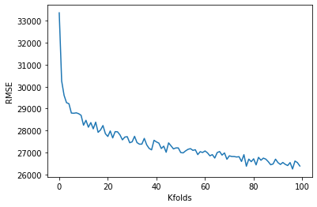

```python
data = pd.read_csv("AmesHousing.tsv", delimiter='\t')

transformed_data = transform_features(data)
final_data = select_features(transformed_data)

results = []
for i in range(100):
    result = train_and_test(final_data, k=i)
    results.append(result)

x = [i for i in range(100)]
y = results
plt.plot(x, y)
plt.xlabel('Kfolds')
plt.ylabel('RMSE')
```